# Lecture 3 - Ahmed’s Submission

Ahmed Nadeem

2024-10-03

We’re going to simulate some data that can be used in each of the following tests.

The response variable is normally distributed, and then we’re going to back calculate some predictor variables.

NOTE: There are 9 questions below to answer. Do your best to answer them in full sentences. This is part of what we’re practicing in this class.

QUESTION: Describe the trait that you’re simulating. This can be a real trait that you are working on, or hope to work on, or it can be completely made up. Pay special attention to the N that you’re expecting, the mean, and the sd around the mean.

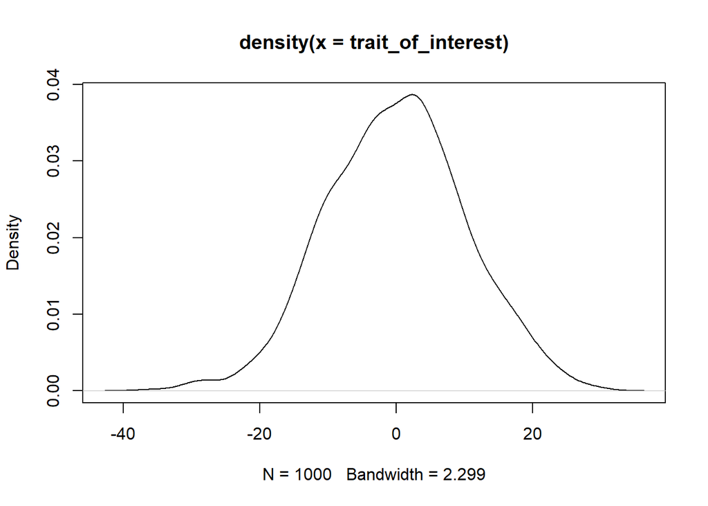

```r
rnorm(1000, 0, 10)->trait_of_interest ### change this to be a trait that you're actually interested in, with an appropriate distribution!

plot(density(trait_of_interest))
```

```r
min(trait_of_interest)
```

```
## [1] -35.91609
```

```r
max(trait_of_interest)
```

```
## [1] 29.41262
```

QUESTION: Describe the predictor variable. What does this mean biologically to your trait of interest. How did you decide on the numbers in yes on line 33?

```r
yes<-sample(trait_of_interest, 500, replace=FALSE, prob = ifelse(trait_of_interest>0, 0.95, 0.15)) #### play with this line! Is the test statistically significant. When is it not?
predictor_t.test<-(trait_of_interest %in% yes)

cbind.data.frame(trait_of_interest, predictor_t.test)->data

mean(data[which(data$predictor_t.test==TRUE),1])
```

```
## [1] 4.559391
```

```r
mean(data[which(data$predictor_t.test==FALSE),1])
```

```
## [1] -4.503646
```

```r
t.test(trait_of_interest~predictor_t.test, data=data) ### this does a two sample t-test. What would a one sample t test be testing? How would you do that?
```

```
##
##  Welch Two Sample t-test
##
## data:  trait_of_interest by predictor_t.test
## t = -15.731, df = 998, p-value < 2.2e-16
## alternative hypothesis: true difference in means between group FALSE and group TRUE is not equal to 0
## 95 percent confidence interval:
##  -10.193575  -7.932498
## sample estimates:
## mean in group FALSE  mean in group TRUE
##           -4.503646            4.559391
```

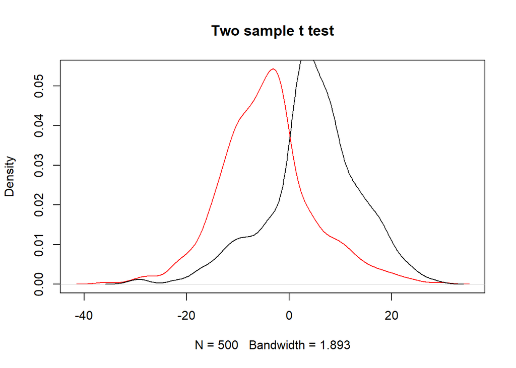

```r
### plots our two samples for distribution
plot(density(data[which(data$predictor_t.test==FALSE),1]), col="red", main="Two sample t test")
lines(density(data[which(data$predictor_t.test==TRUE),1]), ylim=c(0, 0.1), xlim=c(-20,20), main="Two Sample T test")
```

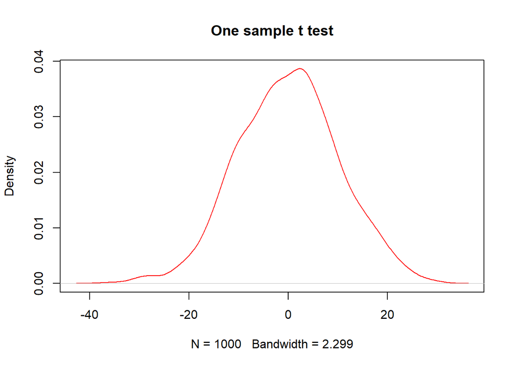

```r
###plot one sample distribution
plot(density(data$trait_of_interest), col="red", main="One sample t test")
```

```r
t.test(data$trait_of_interest) ### what is this test doing?
```

```
##
##  One Sample t-test
##
## data:  data$trait_of_interest
## t = 0.086659, df = 999, p-value = 0.931
## alternative hypothesis: true mean is not equal to 0
## 95 percent confidence interval:
##  -0.6032870  0.6590322
## sample estimates:
##  mean of x
## 0.02787264
```

QUESTION: Write one sentence where you report your t.text.

Next we’re going to move to Anova. So, the first thing we’ll do is break our response variable (same one!) into 5 different categories, just as we did for the t-tests.

QUESTION: Describe the predictor variable. What does this mean biologically to your trait of interest. How did you decide on the numbers in lines 60, 61, 62, 63?

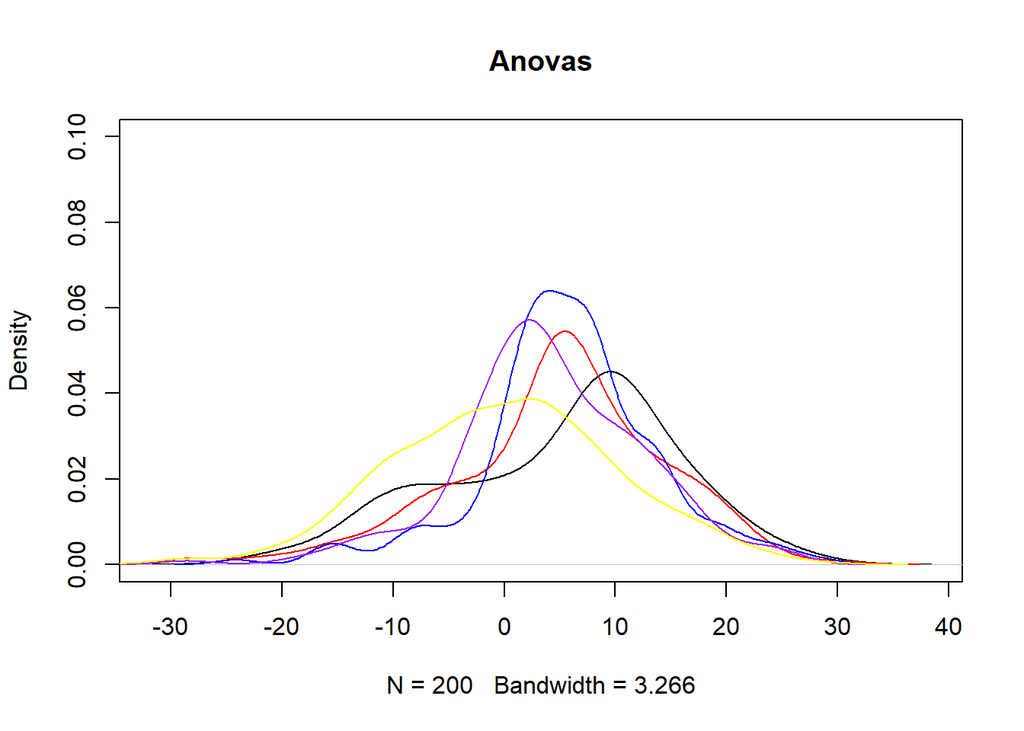

```r
test1<-sample(trait_of_interest, 200, replace=FALSE, prob = ifelse(trait_of_interest>7, 0.95, 0.15))
test2<-sample(trait_of_interest[which(trait_of_interest %in% test1 == FALSE)], 200, replace=FALSE, prob = ifelse(trait_of_interest[which(trait_of_interest %in% test1 == FALSE)] >4, 0.95, 0.15))
test3<-sample(trait_of_interest[which(trait_of_interest %in% test2 == FALSE | trait_of_interest %in% test1 ==FALSE)], 200, replace=FALSE, prob = ifelse(trait_of_interest[which(trait_of_interest %in% test2 == FALSE | trait_of_interest %in% test1 == FALSE)] >0, 0.95, 0.15))
test4<-sample(trait_of_interest[which(trait_of_interest %in% test2 == FALSE | trait_of_interest %in% test1 ==FALSE | trait_of_interest %in% test3 == FALSE)], 200, replace=FALSE, prob = ifelse(trait_of_interest[which(trait_of_interest %in% test2 == FALSE | trait_of_interest %in% test1 ==FALSE | trait_of_interest %in% test3 == FALSE)] >-4, 0.95, 0.15))
test5<-trait_of_interest[which(trait_of_interest %in% test1 == FALSE| trait_of_interest %in% test2 == FALSE | trait_of_interest %in% test3 == FALSE | trait_of_interest %in% test4 == FALSE)]


plot(density(test1), ylim=c(0, 0.1), main="Anovas")
lines(density(test2), col="red")
lines(density(test3), col="blue")
lines(density(test4), col="purple")
lines(density(test5), col="yellow")
```

```r
anova_predictor<-data.frame(ifelse(trait_of_interest %in% test1 == TRUE, "group1", ifelse(trait_of_interest %in% test2 == TRUE, "group2", ifelse(trait_of_interest %in% test3 == TRUE, "group3", ifelse(trait_of_interest %in% test4 == TRUE, "group4", "group5")))))

data2<-cbind.data.frame(data, anova_predictor)
names(data2)<-c("trait_of_interest", "predictor_t.test", "anova_predictor")


anova(aov(trait_of_interest~anova_predictor, data=data2)) ### what does this do?
```

```
## Analysis of Variance Table
##
## Response: trait_of_interest
##                  Df Sum Sq Mean Sq F value    Pr(>F)
## anova_predictor   4  20671  5167.7  62.193 < 2.2e-16 ***
## Residuals       995  82676    83.1
## ---
## Signif. codes:  0 '***' 0.001 '**' 0.01 '*' 0.05 '.' 0.1 ' ' 1
```

```r
anova(lm(trait_of_interest~anova_predictor, data=data2)) ### what does this do?
```

```
## Analysis of Variance Table
##
## Response: trait_of_interest
##                  Df Sum Sq Mean Sq F value    Pr(>F)
## anova_predictor   4  20671  5167.7  62.193 < 2.2e-16 ***
## Residuals       995  82676    83.1
## ---
## Signif. codes:  0 '***' 0.001 '**' 0.01 '*' 0.05 '.' 0.1 ' ' 1
```

```r
summary(aov(trait_of_interest~anova_predictor, data=data2)) ### what does this do? What do you notice about the last three tests?
```

```
##                  Df Sum Sq Mean Sq F value Pr(>F)
## anova_predictor   4  20671    5168   62.19 <2e-16 ***
## Residuals       995  82676      83
## ---
## Signif. codes:  0 '***' 0.001 '**' 0.01 '*' 0.05 '.' 0.1 ' ' 1
```

```r
### what information is missing here that you wished you had to understand your study better?
analysis_of_variance<-aov(trait_of_interest~anova_predictor, data=data2) ##name the model to keep it for downstream
TukeyHSD(analysis_of_variance, conf.level = 0.95) ### what does this do, and where are the differences?
```

```
##   Tukey multiple comparisons of means
##     95% family-wise confidence level
##
## Fit: aov(formula = trait_of_interest ~ anova_predictor, data = data2)
##
## $anova_predictor
##                      diff        lwr        upr     p adj
## group2-group1  -0.3338505  -2.824901  2.1571999 0.9961629
## group3-group1  -3.6091633  -6.771042 -0.4472842 0.0159746
## group4-group1  -5.3314063  -8.481281 -2.1815313 0.0000415
## group5-group1 -10.1585298 -12.299476 -8.0175832 0.0000000
## group3-group2  -3.2753128  -6.437192 -0.1134337 0.0380466
## group4-group2  -4.9975558  -8.147431 -1.8476808 0.0001555
## group5-group2  -9.8246792 -11.965626 -7.6837326 0.0000000
## group4-group3  -1.7222429  -5.425466  1.9809800 0.7091919
## group5-group3  -6.5493664  -9.443464 -3.6552690 0.0000000
## group5-group4  -4.8271235  -7.708101 -1.9461458 0.0000517
```

QUESTION: Write one sentence where you report your ANOVA and Tukey tests. What did you find, and how do you report this?

Again, our simulations aren’t to be actually causal, I’m simulating predictor variables to fit a response I’ve already made. Normally, we would simulate the response variables from more thoughtful predictor variables.

QUESTION:what is the difference between the assumed distributions for the prior predictor variables, and this one?

QUESTION: Describe the predictor variable. What does this mean biologically to your trait of interest. How did you decide on the numbers in line 104?

QUESTION: What is the difference between a regression and a correlation? When would you use each? How does the test stat from the correlation compare to the effect size from the regression?

```r
linear_regression_predictor<-0.5*trait_of_interest+rnorm(1000, 0, 4) ### change these numbers!! Remember that this is backwards from how we did this on day 1, so the slope should go the other way!
data3<-cbind(data2, linear_regression_predictor)

lm<-lm(trait_of_interest~linear_regression_predictor, data=data3)
summary(lm)### what is the output here? What are we interested in understanding from this model? How do we get m? How do we get the intercept?
```

```
##
## Call:
## lm(formula = trait_of_interest ~ linear_regression_predictor,
##     data = data3)
##
## Residuals:
##      Min       1Q   Median       3Q      Max
## -18.8290  -4.1743   0.1973   4.5490  22.0250
##
## Coefficients:
##                             Estimate Std. Error t value Pr(>|t|)
## (Intercept)                 0.008381   0.198695   0.042    0.966
## linear_regression_predictor 1.199805   0.029812  40.246   <2e-16 ***
## ---
## Signif. codes:  0 '***' 0.001 '**' 0.01 '*' 0.05 '.' 0.1 ' ' 1
##
## Residual standard error: 6.283 on 998 degrees of freedom
## Multiple R-squared:  0.6188, Adjusted R-squared:  0.6184
## F-statistic:  1620 on 1 and 998 DF,  p-value: < 2.2e-16
```

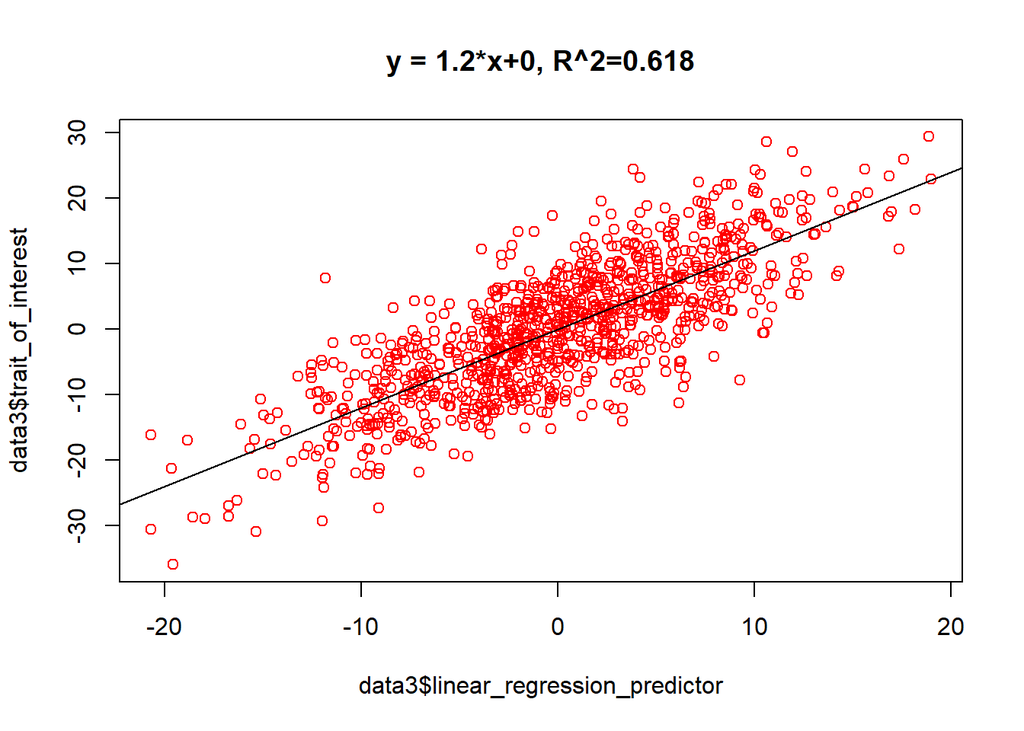

```r
eq = paste0("y = ", round(lm$coefficients[2],1), "*x", "+",round(lm$coefficients[1],1), ", R^2=", round(summary(lm)$adj.r.squared, digits=3))
plot(data3$linear_regression_predictor, data3$trait_of_interest, col="red", main=eq)
abline(lm, col="black")
```

```r
### with the same data:
cor.test(data3$trait_of_interest, data3$linear_regression_predictor) ### compare the sample estimate to the 1) simulated effect sizes and 2) to the estimated effect size
```

```
##
##  Pearson's product-moment correlation
##
## data:  data3$trait_of_interest and data3$linear_regression_predictor
## t = 40.246, df = 998, p-value < 2.2e-16
## alternative hypothesis: true correlation is not equal to 0
## 95 percent confidence interval:
##  0.7617622 0.8091443
## sample estimates:
##       cor
## 0.7866085
```

```r
### how does the correlation estimate change when you change line 104?
```

QUESTION: Report your regression and correlation in a sentence. Differentiate between them and what you report for each.